# MTH6139 Time Series

Coursework 1 – Tesla Stock Time Series

AARON SIRCAR

Spring term 2025

# Section 1: Introduction

This report analyzes and forecasts Tesla’s stock prices using the Prophet package in R. The dataset contains historical stock prices of Tesla from 15/09/2014 to 13/09/2024, specifically focusing on the closing prices over time. The goal is to develop a forecasting model to predict future stock prices.

The dataset used has over 2500 datapoints and this is beneficial as it provides more information for the model to identify patterns, trends, and seasonality accurately. Larger datasets reducce the impact of outliers and random noise, improving the reliability of forecasts.

## 1.1 Loading and Preparing the Data

The data used in this analysis was a dataset downloaded from Kaggle and contains daily closing prices for Tesla’s stock.

The dataset was saved in a CSV file called `TESLA_DATA.csv`, placed inside the `data/` folder of this project.

```r
# Loading required libraries
library(readr)
library(prophet)
# Loading the data
tesla_data <- read_csv("data/TESLA_DATA.csv")
# Renaming columns as required by Prophet
colnames(tesla_data)[colnames(tesla_data) == "Date"] <- "ds"
colnames(tesla_data)[colnames(tesla_data) == "Close/Last"] <- "y"

# Check the structure of the data
str(tesla_data)
```

```
## spc_tbl_ [2,517 × 6] (S3: spec_tbl_df/tbl_df/tbl/data.frame)
##  $ ds    : Date[1:2517], format: "2014-09-15" "2014-09-16" ...
##  $ y     : num [1:2517] 16.9 17.4 17.4 17.6 17.3 ...
##  $ Volume: num [1:2517] 2.47e+08 1.24e+08 7.76e+07 5.53e+07 1.02e+08 ...
##  $ Open  : num [1:2517] 18.3 17 17.5 17.6 17.2 ...
##  $ High  : num [1:2517] 18.3 17.5 17.6 17.7 17.4 ...
##  $ Low   : num [1:2517] 16.6 16.8 17.3 17.5 17 ...
##  - attr(*, "spec")=
##   .. cols(
##   ..   Date = col_date(format = ""),
##   ..   `Close/Last` = col_double(),
##   ..   Volume = col_double(),
##   ..   Open = col_double(),
##   ..   High = col_double(),
##   ..   Low = col_double()
##   .. )
##  - attr(*, "problems")=<externalptr>
```

```r
# View the first few rows
head(tesla_data)
```

```
## # A tibble: 6 × 6
##   ds             y    Volume  Open  High   Low
##   <date>     <dbl>     <dbl> <dbl> <dbl> <dbl>
## 1 2014-09-15  16.9 246507477  18.3  18.3  16.6
## 2 2014-09-16  17.4 124461748  17.0  17.5  16.8
## 3 2014-09-17  17.4  77594871  17.5  17.6  17.3
## 4 2014-09-18  17.6  55342127  17.6  17.7  17.5
## 5 2014-09-19  17.3 102014574  17.2  17.4  17.0
## 6 2014-09-22  16.7 123137728  17    17.1  16.3
```

## 1.2 Visualizing the Data

We can visualize the dataset with a basic plot.

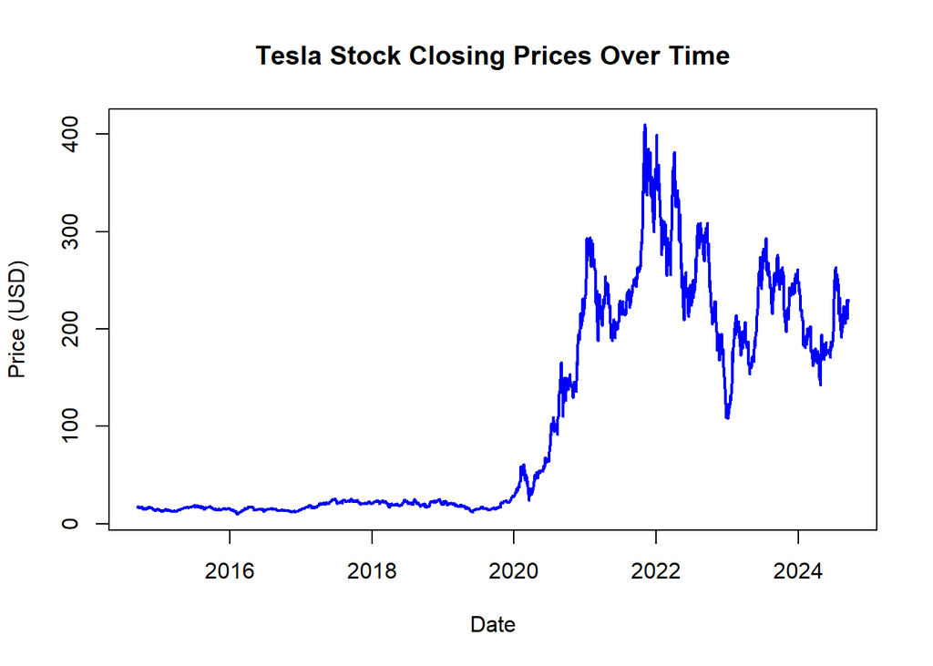

```r
# Basic plot of Tesla closing prices over time
plot(tesla_data$ds, tesla_data$y, type = "l",
     main = "Tesla Stock Closing Prices Over Time",
     xlab = "Date", ylab = "Price (USD)",
     col = "blue", lwd = 2)
```

# Section 2: Forecasting with Prophet

## 2.1 Fitting the Prophet Model

Now we fit the Prophet model to the data.

```r
# Fit the Prophet model
tesla_model <- prophet(tesla_data)
```

```
## Disabling daily seasonality. Run prophet with daily.seasonality=TRUE to override this.
```

## 2.2 Creating Future Dataframes

We create future data frames to forecast Tesla’s stock price for the next 1 year as well as the next 5 years.

```r
# Create a future dataframe with 365 additional days
future_1yr <- make_future_dataframe(tesla_model, periods = 365)

# Create a future dataframe for the next 5 years
future_5yr <- make_future_dataframe(tesla_model, periods = 1825)

# Display the tail of the future dataframes
tail(future_1yr)
```

```
##              ds
## 2877 2025-09-08
## 2878 2025-09-09
## 2879 2025-09-10
## 2880 2025-09-11
## 2881 2025-09-12
## 2882 2025-09-13
```

```r
tail(future_5yr)
```

```
##              ds
## 4337 2029-09-07
## 4338 2029-09-08
## 4339 2029-09-09
## 4340 2029-09-10
## 4341 2029-09-11
## 4342 2029-09-12
```

## 2.3 Forecasting and Plotting Results

We use the `predict` function to forecast future values, then plot the forecast.

```r
# Make the 1 year forecast
forecast_1yr <- predict(tesla_model, future_1yr)

forecast_5yr <- predict(tesla_model, future_5yr)

# View the tail of the forecast data
tail(forecast_1yr)
```

```
##              ds    trend additive_terms additive_terms_lower
## 2877 2025-09-08 186.4807       10.49064             10.49064
## 2878 2025-09-09 186.4424       10.24153             10.24153
## 2879 2025-09-10 186.4041       10.59244             10.59244
## 2880 2025-09-11 186.3658       10.22225             10.22225
## 2881 2025-09-12 186.3275       10.08011             10.08011
## 2882 2025-09-13 186.2892       12.90629             12.90629
##      additive_terms_upper      weekly weekly_lower weekly_upper   yearly
## 2877             10.49064 -0.05789658  -0.05789658  -0.05789658 10.54854
## 2878             10.24153 -0.53274155  -0.53274155  -0.53274155 10.77427
## 2879             10.59244 -0.38192908  -0.38192908  -0.38192908 10.97437
## 2880             10.22225 -0.92070393  -0.92070393  -0.92070393 11.14295
## 2881             10.08011 -1.19410818  -1.19410818  -1.19410818 11.27422
## 2882             12.90629  1.54368960   1.54368960   1.54368960 11.36260
##      yearly_lower yearly_upper multiplicative_terms multiplicative_terms_lower
```

[output cut: 20 more lines]

```r
tail(forecast_5yr)
```

```
##              ds    trend additive_terms additive_terms_lower
## 4337 2029-09-07 130.5676       9.108856             9.108856
## 4338 2029-09-08 130.5293      12.092228            12.092228
## 4339 2029-09-09 130.4910      12.317959            12.317959
## 4340 2029-09-10 130.4527      10.916471            10.916471
## 4341 2029-09-11 130.4144      10.610210            10.610210
## 4342 2029-09-12 130.3761      10.892287            10.892287
##      additive_terms_upper      weekly weekly_lower weekly_upper   yearly
## 4337             9.108856 -1.19410818  -1.19410818  -1.19410818 10.30296
## 4338            12.092228  1.54368960   1.54368960   1.54368960 10.54854
## 4339            12.317959  1.54368972   1.54368972   1.54368972 10.77427
## 4340            10.916471 -0.05789658  -0.05789658  -0.05789658 10.97437
## 4341            10.610210 -0.53274155  -0.53274155  -0.53274155 11.14295
## 4342            10.892287 -0.38192908  -0.38192908  -0.38192908 11.27422
##      yearly_lower yearly_upper multiplicative_terms multiplicative_terms_lower
```

[output cut: 20 more lines]